# dashboard – Pathogen Surveillance

This report is produced by the [**`nf-core/pathogensurveillance`**](https://nf-co.re/pathogensurveillance) pipeline.

Pipeline Status

The pipeline finished execution. Warning or error messages describing problems encountered in the analysis might be provided below.

**Summary**

✅ **No issues reported.**

**Details**

This is a list of issues reported by the pipeline during execution. When relevant, the sample IDs or reference IDs associated with the issue are included.

|  | Type | Sample ID | Reference ID | Pipeline Step | Message |
| --- | --- | --- | --- | --- | --- |

Input Data

|  | sample_id | name | description | path | path_2 | ncbi_accession | ncbi_query | ncbi_query_max | sequence_type | report_group_ids | color_by | ploidy | enabled | ref_contextual_usage | ref_enabled | species | report_group_ids_old | latitude | longitude | single_end | sendsketch_depth | domain |
| --- | --- | --- | --- | --- | --- | --- | --- | --- | --- | --- | --- | --- | --- | --- | --- | --- | --- | --- | --- | --- | --- | --- |
| 1 | SAMEA3880302 | N. meningitidis | N. meningitidis |  |  | ERR1556258 |  | 10 | illumina | all | species | 1 | True | optional | True | Neisseria meningitidis | all;n_meningitidis | 43.902114 | -72.641602 |  | 22.811 | Bacteria |
| 2 | SAMEA882280 | K. pneumoniae | K. pneumoniae |  |  | ERR024826 |  | 10 | illumina | all | species | 1 | True | optional | True | Klebsiella pneumoniae | all;k_pneumoniae | 32.403463 | -109.555664 |  | 5.63 | Bacteria |
| 3 | SAMN11100993 | M. abscessus | M. abscessus |  |  | SRR12574849 |  | 10 | illumina | all | species | 1 | True | optional | True | Mycobacteroides abscessus | all;m_abscessus | 43.93377 | -74.575195 |  | 26.274 | Bacteria |
| 4 | SAMEA3880305 | N. meningitidis | N. meningitidis |  |  | ERR1556259 |  | 10 | illumina | all | species | 1 | True | optional | True | Neisseria meningitidis | all;n_meningitidis | 43.32944 | -68.115234 |  | 23.956 | Bacteria |
| 5 | SAMN11100994 | M. abscessus | M. abscessus |  |  | SRR12574848 |  | 10 | illumina | all | species | 1 | True | optional | True | Mycobacteroides abscessus | all;m_abscessus | 43.457172 | -74.047852 |  | 45.323 | Bacteria |
| 6 | SAMN11100995 | M. abscessus | M. abscessus |  |  | SRR12574847 |  | 10 | illumina | all | species | 1 | True | optional | True | Mycobacteroides abscessus | all;m_abscessus | 43.965408 | -73.212891 |  | 42.419 | Bacteria |
| 7 | SAMN11100996 | M. abscessus | M. abscessus |  |  | SRR12574846 |  | 10 | illumina | all | species | 1 | True | optional | True | Mycobacteroides abscessus | all;m_abscessus | 33.948221 | -84.023438 |  | 33.418 | Bacteria |
| 8 | SAMEA3880307 | N. meningitidis | N. meningitidis |  |  | ERR1556260 |  | 10 | illumina | all | species | 1 | True | optional | True | Neisseria meningitidis | all;n_meningitidis | 41.262393 | -76.552734 |  | 25.461 | Bacteria |
| 9 | SAMEA882278 | K. pneumoniae | K. pneumoniae |  |  | ERR024824 |  | 10 | illumina | all | species | 1 | True | optional | True | Klebsiella pneumoniae | all;k_pneumoniae | 31.508625 | -107.753906 |  | 10.253 | Bacteria |
| 10 | SAMEA882273 | K. pneumoniae | K. pneumoniae |  |  | ERR024827 |  | 10 | illumina | all | species | 1 | True | optional | True | Klebsiella pneumoniae | all;k_pneumoniae | 32.403463 | -99.887695 |  | 6.583 | Bacteria |

[interactive chart not shown]

Initial Identification

**Taxonomic classification summary**

[interactive chart not shown]

**Per-sample classification**

| Sample | WKID (%) | ANI (%) | Completeness (%) | Top Hit |
| --- | --- | --- | --- | --- |
| SAMN11100996 | 86.87 | 99.49 | 100 | Mycobacteroides abscessus subsp. massiliense CCUG 48898 = JCM 15300 |
| SAMEA3880305 | 99.44 | 99.98 | 100 | Neisseria meningitidis 2006087 |
| SAMN11100995 | 83.2 | 99.33 | 100 | Mycobacteroides abscessus UC22 |
| SAMEA3880307 | 99.47 | 99.98 | 100 | Neisseria meningitidis 2004032 |
| SAMEA3880302 | 97.73 | 99.92 | 100 | Neisseria meningitidis 2003051 |
| SAMN11100993 | 87.02 | 99.5 | 100 | Mycobacteroides abscessus M94 |
| SAMN11100994 | 88.34 | 99.55 | 100 | Mycobacteroides abscessus 9808 |
| SAMEA882280 | 76.73 | 99.05 | 100 | Klebsiella sp. HMSC22F09 |
| SAMEA882273 | 75.51 | 98.99 | 100 | Klebsiella variicola At-22 |
| SAMEA882278 | 85.06 | 99.41 | 100 | Klebsiella sp. 4_1_44FAA |

**About**

**Plot**

The plot shows the distribution of tentative taxonomic classifications for all samples. Only the “highest scoring” results for each sample is considered.

Hover your cursor over parts of the sunburst plot will display the number of samples in each taxon. Clicking on a section will subset the plot to that taxon. Clicking on the middle will undo the subset.

**Table**

The table shows the “highest scoring” tentative taxonomic classification for each sample. Included metrics can provide insights into how each sample compares with reference genomes on online databases and the likelihood these comparisons are valid.

- **Sample:** The sample ID submitted by the user.
- **WKID:** Weighted k-mer Identity, adjusted for genome size differences.
- **ANI:** An estimate of average nucleotide identity (ANI), derived from WKID and kmer length.
- **Completeness:** The percentage of the reference genome represented in the query.
- **Top Hit:** The name of the reference genome most similar to each sample based on the scoring criteria used.

Most similar organisms

**ANI top matches**

|  | Sample | Closest reference | Reference ANI (%) | Closest sample | Sample ANI (%) |
| --- | --- | --- | --- | --- | --- |
| 1 | N. meningitidis | Neisseria sp. HMSC070F02 | 0.9860 | N. meningitidis | 0.9917 |
| 2 | K. pneumoniae | Klebsiella sp. HMSC22F09 | 0.9929 | K. pneumoniae | 0.9911 |
| 3 | M. abscessus | Mycobacteroides abscessus subsp. abscessus | 0.9930 | M. abscessus | 0.9944 |
| 4 | N. meningitidis | Neisseria meningitidis | 0.9845 | N. meningitidis | 0.9851 |
| 5 | M. abscessus | Mycobacteroides abscessus subsp. abscessus | 0.9928 | M. abscessus | 0.9944 |
| 6 | M. abscessus | Mycobacteroides abscessus subsp. abscessus | 0.9928 | M. abscessus | 0.9931 |
| 7 | M. abscessus | Mycobacteroides abscessus subsp. abscessus | 0.9779 | M. abscessus | 0.9781 |
| 8 | N. meningitidis | Neisseria sp. HMSC070F02 | 0.9851 | N. meningitidis | 0.9917 |
| 9 | K. pneumoniae | Klebsiella sp. 4_1_44FAA | 0.9948 | K. pneumoniae | 0.9577 |
| 10 | K. pneumoniae | Klebsiella sp. T11 | 0.9915 | K. pneumoniae | 0.9911 |

**ANI heatmap**

[interactive chart not shown]

**POCP top matches**

[output not shown]

**POCP heatmap**

[interactive chart not shown]

**About**

**About ANI Heatmap:** This plot shows the results of comparing the similarity of all samples and references to each other. These similarity metrics are based on the presence and abundance of short exact sequence matches between samples (i.e. comparisons of k-mer sketches). These measurements are not as reliable as the methods used to create phylogenetic trees, but may be useful if phylogenetic trees could not be inferred for these samples.

**About POCP Top Matches:** This table shows the Percentage Of Conserved Proteins (POCP) between each sample and the 2 references most similar to it based on this measure. POCP is used to measure the proportion of proteins shared between two genomes. Which proteins are shared is determined from pairwise comparisons of all proteins between all genomes. The POCP between two genomes is the sum of the number of shared proteins in each genome divided by the sum of the number of total proteins in each genome (Qin et al. 2014). Currently, POCP is only calculated for Prokaryotes.

**About POCP Heatmap:** This plot shows the results of comparing the protein content of all samples and references to each other. POCP is used to measure the proportion of proteins shared between two genomes. Which proteins are shared is determined from pairwise comparisons of all proteins between all genomes. The POCP between two genomes is the sum of the number of shared proteins in each genome divided by the sum of the number of total proteins in each genome (Qin et al. 2014). Currently, POCP is only calculated for Prokaryotes.

Multigene Phylogeny

[interactive chart not shown]

Minimum spanning network

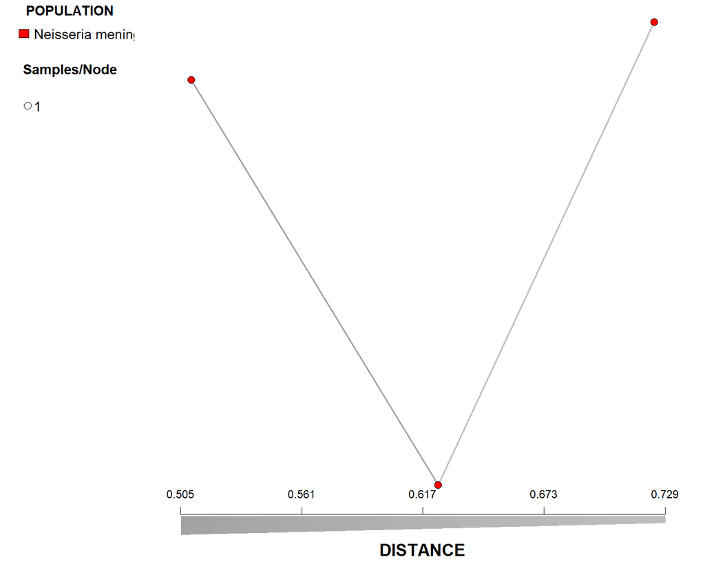

SNP trees

[interactive chart not shown]

Methods

The `pathogen surveillance` pipeline used the following tools that should be referenced as appropriate:

- A sample is first identified to genus using sendsketch and further identified to species using sourmash (Brown and Irber 2016).
- The `nextflow` data-driven computational pipeline enables deployment of complex parallel and reactive workflows (Di Tommaso et al. 2017).

**Analysis Software**

| module | program | version | citation |
| --- | --- | --- | --- |
| ASSIGN_CORE_REFERENCES | r-base | 4.2.1 | R Core Team (2021) |
| ASSIGN_MAPPING_REFERENCE | r-base | 4.2.1 | R Core Team (2021) |
| BAKTA_BAKTA | bakta | 1.11.4 | Schwengers et al. (2021) |
| BAKTA_BAKTADBDOWNLOAD | bakta | 1.11.4 | Schwengers et al. (2021) |
| BUSCO_DOWNLOAD | busco | 5.8.3 | Manni et al. (2021) |
| BWA_INDEX | bwa | 0.7.19-r1273 | Li and Durbin (2009) |
| BWA_MEM | bwa | 0.7.19-r1273 | Li and Durbin (2009) |
| BWA_MEM | samtools | 1.22.1 | Danecek et al. (2021) |
| CALCULATE_POCP | r-base | 4.2.1 | R Core Team (2021) |
| EXTRACT_FEATURE_SEQUENCES | pirate | 1.0.5 | Bayliss et al. (2019) |
| FASTP | fastp | 1.0.1 | Chen (2023) |
| FASTQC | fastqc | 0.12.1 | Andrews et al. (2010) |
| GATK4_VARIANTFILTRATION | gatk4 | 4.6.2.0 | Van der Auwera and O’Connor (2020) |
| GRAPHTYPER_GENOTYPE | graphtyper | 2.7.7 | Eggertsson et al. (2017) |
| GRAPHTYPER_VCFCONCATENATE | graphtyper | 2.7.7 | Eggertsson et al. (2017) |
| IQTREE_CORE | iqtree | 2.4.0 | Nguyen et al. (2015) |
| IQTREE_SNP | iqtree | 2.4.0 | Nguyen et al. (2015) |
| MAFFT_CORE | mafft | v7.520 (2023/Mar/22) | Katoh et al. (2002) |
| MAFFT_CORE | pigz | 2.8 | NA |
| MAKE_GFF_WITH_FASTA | sed | 4.8 | NA |
| PICARD_CREATESEQUENCEDICTIONARY | picard | 3.4.0 | “Picard Toolkit” (2019) |
| PICARD_FORMAT | picard | 3.3.0 | “Picard Toolkit” (2019) |
| PIRATE | pirate | 1.0.5 | Bayliss et al. (2019) |
| QUAST | quast | 5.3.0 | Mikheenko et al. (2018) |
| REFORMAT_PIRATE_RESULTS | pirate | 1.0.5 | Bayliss et al. (2019) |
| SAMPLESHEET_CHECK | r-PathoSurveilR | 1.2.0 | NA |
| SAMTOOLS_FAIDX | samtools | 1.22.1 | Danecek et al. (2021) |
| SAMTOOLS_INDEX | samtools | 1.22.1 | Danecek et al. (2021) |
| SOURMASH_COMPARE | sourmash | 4.9.4 | Brown and Irber (2016) |
| SOURMASH_SKETCH | sourmash | 4.9.4 | Brown and Irber (2016) |
| SPADES | spades | 4.1.0 | Prjibelski et al. (2020) |
| SUBSET_CORE_GENES | r-base | 4.2.1 | R Core Team (2021) |
| TABIX_BGZIP | tabix | 1.21 | Li (2011) |
| TABIX_TABIX | tabix | 1.21 | Li (2011) |
| VCFLIB_VCFFILTER | vcflib | 1.0.14 | Garrison et al. (2022) |
| VCF_TO_SNP_ALIGN | r-base | 4.2.1 | R Core Team (2021) |
| Workflow | nf-core/pathogensurveillance | v1.2.0dev |  |
| Workflow | Nextflow | 25.10.3 | Di Tommaso et al. (2017) |

**R Packages**

**References**

Andrews, Simon et al. 2010. “FastQC: A Quality Control Tool for High Throughput Sequence Data.” Cambridge, United Kingdom.

Bayliss, Sion C, Harry A Thorpe, Nicola M Coyle, Samuel K Sheppard, and Edward J Feil. 2019. “PIRATE: A Fast and Scalable Pangenomics Toolbox for Clustering Diverged Orthologues in Bacteria.” Gigascience 8 (10): giz119.

Brown, C Titus, and Luiz Irber. 2016. “Sourmash: A Library for MinHash Sketching of DNA.” Journal of Open Source Software 1 (5): 27.

Chen, Shifu. 2023. “Ultrafast One-Pass FASTQ Data Preprocessing, Quality Control, and Deduplication Using Fastp.” Imeta 2 (2): e107.

Danecek, Petr, James K Bonfield, Jennifer Liddle, John Marshall, Valeriu Ohan, Martin O Pollard, Andrew Whitwham, et al. 2021. “Twelve Years of SAMtools and BCFtools.” Gigascience 10 (2): giab008.

Di Tommaso, Paolo, Maria Chatzou, Evan W Floden, Pablo Prieto Barja, Emilio Palumbo, and Cedric Notredame. 2017. “Nextflow Enables Reproducible Computational Workflows.” Nature Biotechnology 35 (4): 316–19.

Distribution, Anaconda Software. 2016. “Computer Software.” Vers. 4: 2–2.

Eggertsson, Hannes P, Hakon Jonsson, Snaedis Kristmundsdottir, Eirikur Hjartarson, Birte Kehr, Gisli Masson, Florian Zink, et al. 2017. “Graphtyper Enables Population-Scale Genotyping Using Pangenome Graphs.” Nature Genetics 49 (11): 1654–60.

Garrison, Erik, Zev N Kronenberg, Eric T Dawson, Brent S Pedersen, and Pjotr Prins. 2022. “A Spectrum of Free Software Tools for Processing the VCF Variant Call Format: Vcflib, Bio-Vcf, Cyvcf2, Hts-Nim and Slivar.” PLoS Computational Biology 18 (5): e1009123.

Katoh, Kazutaka, Kazuharu Misawa, Kei-ichi Kuma, and Takashi Miyata. 2002. “MAFFT: A Novel Method for Rapid Multiple Sequence Alignment Based on Fast Fourier Transform.” Nucleic Acids Research 30 (14): 3059–66.

Kurtzer, Gregory M, Vanessa Sochat, and Michael W Bauer. 2017. “Singularity: Scientific Containers for Mobility of Compute.” PloS One 12 (5): e0177459.

Li, Heng. 2011. “Tabix: Fast Retrieval of Sequence Features from Generic TAB-Delimited Files.” Bioinformatics 27 (5): 718–19.

Li, Heng, and Richard Durbin. 2009. “Fast and Accurate Short Read Alignment with Burrows–Wheeler Transform.” Bioinformatics 25 (14): 1754–60.

Manni, Mosè, Matthew R Berkeley, Mathieu Seppey, Felipe A Simão, and Evgeny M Zdobnov. 2021. “BUSCO Update: Novel and Streamlined Workflows Along with Broader and Deeper Phylogenetic Coverage for Scoring of Eukaryotic, Prokaryotic, and Viral Genomes.” Molecular Biology and Evolution 38 (10): 4647–54.

Mikheenko, Alla, Andrey Prjibelski, Vladislav Saveliev, Dmitry Antipov, and Alexey Gurevich. 2018. “Versatile Genome Assembly Evaluation with QUAST-LG.” Bioinformatics 34 (13): i142–50.

Nguyen, Lam-Tung, Heiko A Schmidt, Arndt Von Haeseler, and Bui Quang Minh. 2015. “IQ-TREE: A Fast and Effective Stochastic Algorithm for Estimating Maximum-Likelihood Phylogenies.” Molecular Biology and Evolution 32 (1): 268–74.

“Picard Toolkit.” 2019. Broad Institute, GitHub Repository. https://broadinstitute.github.io/picard/; Broad Institute.

Prjibelski, Andrey, Dmitry Antipov, Dmitry Meleshko, Alla Lapidus, and Anton Korobeynikov. 2020. “Using SPAdes de Novo Assembler.” Current Protocols in Bioinformatics 70 (1): e102.

Qin, Qi-Long, Bin-Bin Xie, Xi-Ying Zhang, Xiu-Lan Chen, Bai-Cheng Zhou, Jizhong Zhou, Aharon Oren, and Yu-Zhong Zhang. 2014. “A Proposed Genus Boundary for the Prokaryotes Based on Genomic Insights.” Journal of Bacteriology 196 (12): 2210–15.

R Core Team. 2021. R: A Language and Environment for Statistical Computing. Vienna, Austria: R Foundation for Statistical Computing. https://www.R-project.org/.

Schwengers, Oliver, Lukas Jelonek, Marius Alfred Dieckmann, Sebastian Beyvers, Jochen Blom, and Alexander Goesmann. 2021. “Bakta: Rapid and Standardized Annotation of Bacterial Genomes via Alignment-Free Sequence Identification.” Microbial Genomics 7 (11): 000685.

Van der Auwera, Geraldine A, and Brian D O’Connor. 2020. Genomics in the Cloud: Using Docker, GATK, and WDL in Terra. O’Reilly Media.

About

Contributors

The **`nf-core/pathogen surveillance` pipeline** was developed by: Zach Foster, Martha Sudermann, Camilo Parada-Rojas, Logan Blair, Fernanda Iruegas-Bocardo, Ricardo Alcalá-Briseño, [Alexandra Weisberg](https://alexandra-weisberg.com/), [Jeff Chang](http://changlab.cgrb.oregonstate.edu/) and [Nik Grünwald](http://grunwaldlab.cgrb.oregonstate.edu/).

Funding

This pipeline is supported by NIFA grants 2021-67021-34433, 2023-67013-39918 to JHC and NJG and ARS Project 2072-22000-045-000-D to NJG.

Contribute

To contribute, provide feedback, or report bugs please visit our [github repository](https://github.com/nf-core/pathogensurveillance).

Citations

Please cite this pipeline and nf-core in publications as follows:

Foster, ZSL, Sudermann, MA, Parada Rojas, CH, Blair, LK, Iruegas Bocardo, F, Dhakal, U, Weisberg, AJ, Phan, H, Chang, JH, Grunwald, NJ. **PathogenSurveillance: an automated pipeline for population genomic analyses and pathogen identification.** BioRxiv 2025 2025.10.31.685798. doi: https://doi.org/10.1101/2025.10.31.685798

Di Tommaso, Paolo, Maria Chatzou, Evan W Floden, Pablo Prieto Barja, Emilio Palumbo, and Cedric Notredame. 2017. Nextflow Enables Reproducible Computational Workflows. Nature Biotechnology 35: 316–19. https://doi.org/10.1038/nbt.3820.

Other tools

## References

Andrews, Simon et al. 2010. “FastQC: A Quality Control Tool for High Throughput Sequence Data.” Cambridge, United Kingdom.

Bayliss, Sion C, Harry A Thorpe, Nicola M Coyle, Samuel K Sheppard, and Edward J Feil. 2019. “PIRATE: A Fast and Scalable Pangenomics Toolbox for Clustering Diverged Orthologues in Bacteria.” *Gigascience* 8 (10): giz119.

Brown, C Titus, and Luiz Irber. 2016. “Sourmash: A Library for MinHash Sketching of DNA.” *Journal of Open Source Software* 1 (5): 27.

Chen, Shifu. 2023. “Ultrafast One-Pass FASTQ Data Preprocessing, Quality Control, and Deduplication Using Fastp.” *Imeta* 2 (2): e107.

Danecek, Petr, James K Bonfield, Jennifer Liddle, John Marshall, Valeriu Ohan, Martin O Pollard, Andrew Whitwham, et al. 2021. “Twelve Years of SAMtools and BCFtools.” *Gigascience* 10 (2): giab008.

Di Tommaso, Paolo, Maria Chatzou, Evan W Floden, Pablo Prieto Barja, Emilio Palumbo, and Cedric Notredame. 2017. “Nextflow Enables Reproducible Computational Workflows.” *Nature Biotechnology* 35 (4): 316–19.

Eggertsson, Hannes P, Hakon Jonsson, Snaedis Kristmundsdottir, Eirikur Hjartarson, Birte Kehr, Gisli Masson, Florian Zink, et al. 2017. “Graphtyper Enables Population-Scale Genotyping Using Pangenome Graphs.” *Nature Genetics* 49 (11): 1654–60.

Garrison, Erik, Zev N Kronenberg, Eric T Dawson, Brent S Pedersen, and Pjotr Prins. 2022. “A Spectrum of Free Software Tools for Processing the VCF Variant Call Format: Vcflib, Bio-Vcf, Cyvcf2, Hts-Nim and Slivar.” *PLoS Computational Biology* 18 (5): e1009123.

Katoh, Kazutaka, Kazuharu Misawa, Kei-ichi Kuma, and Takashi Miyata. 2002. “MAFFT: A Novel Method for Rapid Multiple Sequence Alignment Based on Fast Fourier Transform.” *Nucleic Acids Research* 30 (14): 3059–66.

Li, Heng. 2011. “Tabix: Fast Retrieval of Sequence Features from Generic TAB-Delimited Files.” *Bioinformatics* 27 (5): 718–19.

Li, Heng, and Richard Durbin. 2009. “Fast and Accurate Short Read Alignment with Burrows–Wheeler Transform.” *Bioinformatics* 25 (14): 1754–60.

Manni, Mosè, Matthew R Berkeley, Mathieu Seppey, Felipe A Simão, and Evgeny M Zdobnov. 2021. “BUSCO Update: Novel and Streamlined Workflows Along with Broader and Deeper Phylogenetic Coverage for Scoring of Eukaryotic, Prokaryotic, and Viral Genomes.” *Molecular Biology and Evolution* 38 (10): 4647–54.

Mikheenko, Alla, Andrey Prjibelski, Vladislav Saveliev, Dmitry Antipov, and Alexey Gurevich. 2018. “Versatile Genome Assembly Evaluation with QUAST-LG.” *Bioinformatics* 34 (13): i142–50.

Nguyen, Lam-Tung, Heiko A Schmidt, Arndt Von Haeseler, and Bui Quang Minh. 2015. “IQ-TREE: A Fast and Effective Stochastic Algorithm for Estimating Maximum-Likelihood Phylogenies.” *Molecular Biology and Evolution* 32 (1): 268–74.

“Picard Toolkit.” 2019. *Broad Institute, GitHub Repository*. https://broadinstitute.github.io/picard/; Broad Institute.

Prjibelski, Andrey, Dmitry Antipov, Dmitry Meleshko, Alla Lapidus, and Anton Korobeynikov. 2020. “Using SPAdes de Novo Assembler.” *Current Protocols in Bioinformatics* 70 (1): e102.

Qin, Qi-Long, Bin-Bin Xie, Xi-Ying Zhang, Xiu-Lan Chen, Bai-Cheng Zhou, Jizhong Zhou, Aharon Oren, and Yu-Zhong Zhang. 2014. “A Proposed Genus Boundary for the Prokaryotes Based on Genomic Insights.” *Journal of Bacteriology* 196 (12): 2210–15.

R Core Team. 2021. *R: A Language and Environment for Statistical Computing*. Vienna, Austria: R Foundation for Statistical Computing. https://www.R-project.org/.

Schwengers, Oliver, Lukas Jelonek, Marius Alfred Dieckmann, Sebastian Beyvers, Jochen Blom, and Alexander Goesmann. 2021. “Bakta: Rapid and Standardized Annotation of Bacterial Genomes via Alignment-Free Sequence Identification.” *Microbial Genomics* 7 (11): 000685.

Van der Auwera, Geraldine A, and Brian D O’Connor. 2020. *Genomics in the Cloud: Using Docker, GATK, and WDL in Terra*. O’Reilly Media.